# HW2

# Introduction

We want to forecast the sales of UGS for every quarter of 2007. We will use the data between 2000 and 2006.

## Packages

```r
library(RcppRoll)
library(readxl)
library(lubridate)
library(zoo)
```

```r
library(ggplot2)
library(scales)
library(data.table)
library(corrplot)
library(ggcorrplot)
library(GGally)
library(forecast)
library(dplyr)
```

### Heads:

PU: Average price of a liter of unleaded gasoline in a quarter, PG: Average price of a liter of diesel gasoline in a quarter, GNP=Grand total for GNP . NUGV= Number of unleaded gasoline using vehicles in the traffic, NDGV= Number of diesel gasoline using vehicles in the traffic , GNPA= Agriculture component of Gross National Product , UGS: Unleaded gasoline sale in a given quarter, RNUV: An index indicating the rate of new unleaded gasoline using vehicles being added to the traffic in a quarter, GNPC= Commerce component of Gross National Product ,

## Data Gathering

```r
getwd()
```

```
## [1] "C:/Users/ALP/Desktop"
```

```r
path <- "C:/Users/ALP/Downloads/IE360_Spring22_HW2_data.csv"

UGS_Data <- read.csv(path,colClasses=c('character',rep('numeric',10)))
colnames(UGS_Data) <- c("Quarters", "UGS", "RNUV","NLPG","PU","PG","NUGV","NDGV","GNPA","GNPC","GNPT")

UGS_Data$Quarters <- as.Date(as.yearqtr(UGS_Data$Quarters, format = "%Y_Q%q"))


UGS_Data_Table <- UGS_Data[c(1:28),]


UGS_Data_Table <- data.table(UGS_Data_Table)
```

## Data Visualization

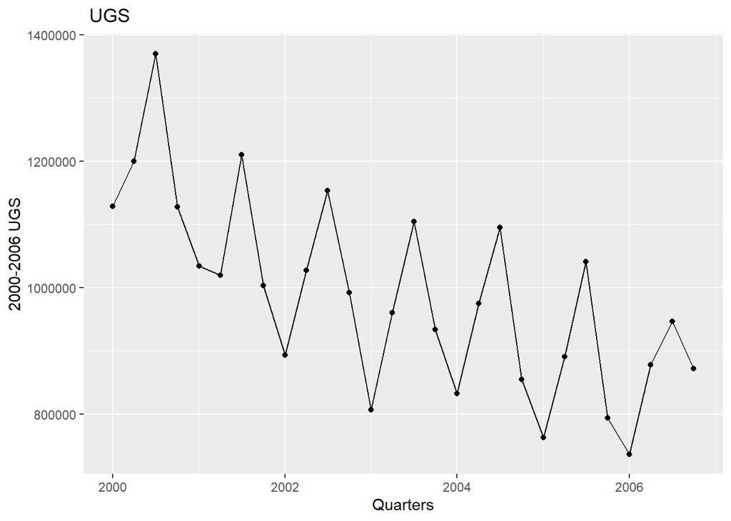

```r
ggplot(UGS_Data_Table, aes(x=Quarters,y=UGS, group = 1)) +
geom_point() +
geom_line() +
labs(y ='2000-2006 UGS')+
ggtitle(' UGS ')
```

We can see an overall declining trend and seasonality with respect to time.Mean of UGS per quarter is not stationary because the means of different parts of the data do not results in same value.But variance looks like stationary and independent of time.

## Autocorrelation Function

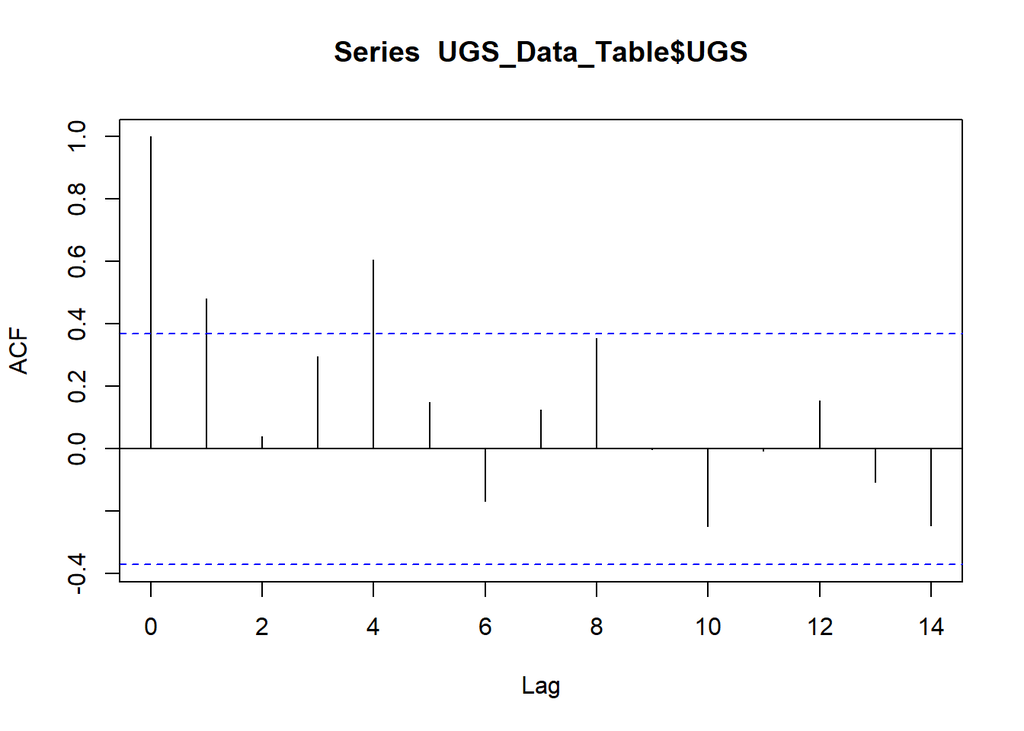

```r
acf(UGS_Data_Table$UGS)
```

We can see that the values for lag 1 and lag 4 are above the limits. lag 4 might be originated from the quarterly seasonality.Also autocorrelation at multiples of 4 is larger than others. autocorrelation at lag 1 is added to model.

## Autocorrelation Plot

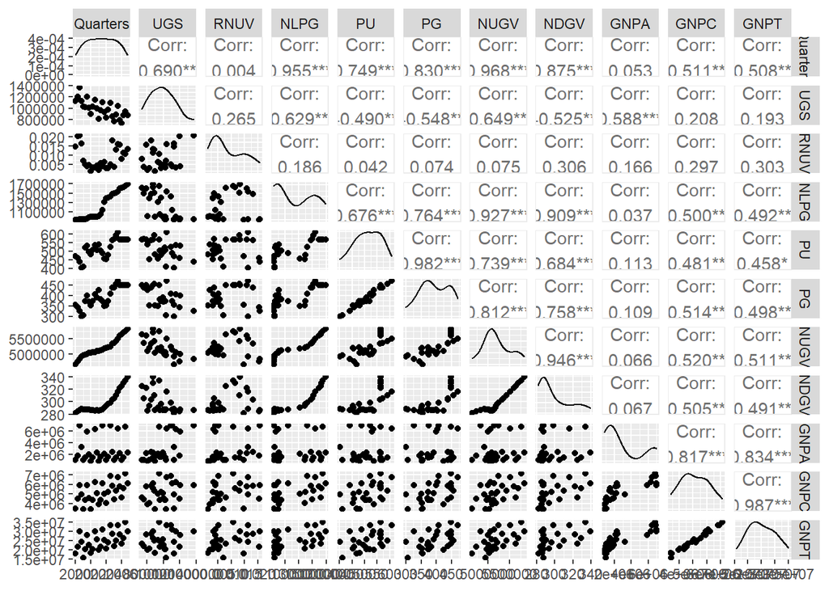

```r
ggpairs(UGS_Data_Table)
```

We can use the ggpairs function to examine independent variables that have a strong correlation with UGS. NLPG, PU, PG, NUGV, NDGV, GNPA, seem to have correlation with UGS

## Model Building.

##Adding Trend and Seasonality

```r
UGS_Data_Table[,trend := 1:.N ]
UGS_Data_Table[,Quarters_:=as.character(month(Quarters))]
UGS_Data_Forecast <- UGS_Data[c(29,30,31,32),]
UGS_Data_Forecast <- data.table(UGS_Data_Forecast)
UGS_Data_Forecast[,trend := 29:32 ]
UGS_Data_Forecast[,Quarters_:=as.character(month(Quarters))]
```

```r
 UGS_Data_Table_Model<- lm(UGS ~ trend+Quarters_, UGS_Data_Table)
summary(UGS_Data_Table_Model)
```

```
##
## Call:
## lm(formula = UGS ~ trend + Quarters_, data = UGS_Data_Table)
##
## Residuals:
##    Min     1Q Median     3Q    Max
## -81167 -31283  -3458  28640  94502
##
## Coefficients:
##             Estimate Std. Error t value Pr(>|t|)
## (Intercept)  1060372      23653  44.830  < 2e-16 ***
## trend         -13497       1147 -11.764 3.28e-11 ***
## Quarters_10    95049      26189   3.629 0.001405 **
## Quarters_4    121532      25987   4.677 0.000104 ***
## Quarters_7    273619      26063  10.498 3.03e-10 ***
## ---
## Signif. codes:  0 '***' 0.001 '**' 0.01 '*' 0.05 '.' 0.1 ' ' 1
##
## Residual standard error: 48570 on 23 degrees of freedom
## Multiple R-squared:  0.9119, Adjusted R-squared:  0.8966
## F-statistic: 59.53 on 4 and 23 DF,  p-value: 8.446e-12
```

We can say the new model is much more preferable because residual standart error is low and R-squared is high.

```r
UGS_Data_Table_Model2 <- lm(UGS ~ trend+NLPG+PU+PG+NUGV+NDGV+GNPA + Quarters_,  UGS_Data_Table)
summary(UGS_Data_Table_Model2)
```

```
##
## Call:
## lm(formula = UGS ~ trend + NLPG + PU + PG + NUGV + NDGV + GNPA +
##     Quarters_, data = UGS_Data_Table)
##
## Residuals:
##    Min     1Q Median     3Q    Max
## -67794 -10461   1987  18461  32208
##
## Coefficients:
##               Estimate Std. Error t value Pr(>|t|)
## (Intercept)  3.094e+06  8.283e+05   3.735  0.00165 **
## trend        1.514e+04  1.284e+04   1.178  0.25486
## NLPG        -2.937e-01  1.804e-01  -1.628  0.12195
## PU           2.276e+01  1.017e+03   0.022  0.98241
## PG          -1.129e+03  1.437e+03  -0.786  0.44295
## NUGV        -1.023e+00  3.343e-01  -3.061  0.00708 **
## NDGV         1.238e+04  3.581e+03   3.456  0.00302 **
## GNPA        -3.613e-02  2.764e-02  -1.307  0.20854
## Quarters_10  1.607e+05  4.385e+04   3.664  0.00192 **
## Quarters_4   1.463e+05  2.356e+04   6.212 9.48e-06 ***
## Quarters_7   4.953e+05  1.597e+05   3.102  0.00648 **
## ---
## Signif. codes:  0 '***' 0.001 '**' 0.01 '*' 0.05 '.' 0.1 ' ' 1
##
## Residual standard error: 29700 on 17 degrees of freedom
## Multiple R-squared:  0.9757, Adjusted R-squared:  0.9613
## F-statistic: 68.12 on 10 and 17 DF,  p-value: 1.055e-11
```

R-squared increased when we add NLPG, PU, PG, NUGV, NDGV, GNPA variables. But we can see that residual standart errors decreased.So our model become better.

## Lagged 1 added to the Model

```r
UGS_Data_Table$UGSlag1=lag(UGS_Data_Table$UGS,1)
UGS_Data_Table_Model3 <-  lm(UGS ~ trend+NLPG+PU+PG+NUGV+NDGV+GNPA +UGSlag1 + Quarters_, UGS_Data_Table)
summary(UGS_Data_Table_Model3)
```

```
##
## Call:
## lm(formula = UGS ~ trend + NLPG + PU + PG + NUGV + NDGV + GNPA +
##     UGSlag1 + Quarters_, data = UGS_Data_Table)
##
## Residuals:
##    Min     1Q Median     3Q    Max
## -49545 -13806  -1137  15516  36779
##
## Coefficients:
##               Estimate Std. Error t value Pr(>|t|)
## (Intercept)  3.657e+06  1.052e+06   3.475 0.003392 **
## trend        5.717e+03  1.702e+04   0.336 0.741633
## NLPG        -2.235e-01  2.120e-01  -1.054 0.308532
## PU          -4.608e+02  1.044e+03  -0.441 0.665160
## PG          -3.671e+02  1.505e+03  -0.244 0.810600
## NUGV        -1.136e+00  4.426e-01  -2.567 0.021468 *
## NDGV         1.387e+04  4.627e+03   2.999 0.008997 **
## GNPA        -6.526e-03  3.479e-02  -0.188 0.853726
## UGSlag1     -4.688e-01  2.491e-01  -1.882 0.079353 .
## Quarters_10  2.072e+05  4.846e+04   4.276 0.000663 ***
## Quarters_4   8.849e+04  3.737e+04   2.368 0.031759 *
## Quarters_7   3.425e+05  1.922e+05   1.782 0.094978 .
## ---
## Signif. codes:  0 '***' 0.001 '**' 0.01 '*' 0.05 '.' 0.1 ' ' 1
##
## Residual standard error: 28110 on 15 degrees of freedom
##   (1 observation deleted due to missingness)
## Multiple R-squared:  0.9801, Adjusted R-squared:  0.9655
## F-statistic: 67.08 on 11 and 15 DF,  p-value: 1.059e-10
```

R-squared increased when we add lagged 1 variable. But we can see that residual standart errors decreased.So our model become much more better.

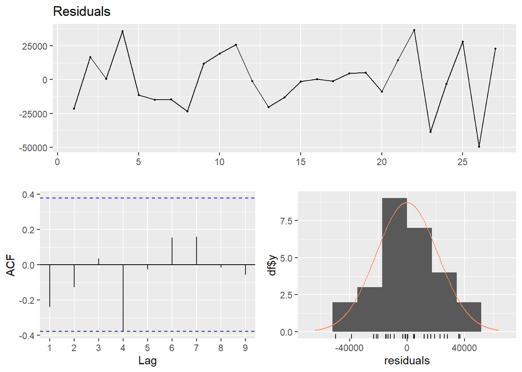

```r
checkresiduals(UGS_Data_Table_Model3$residuals)
```

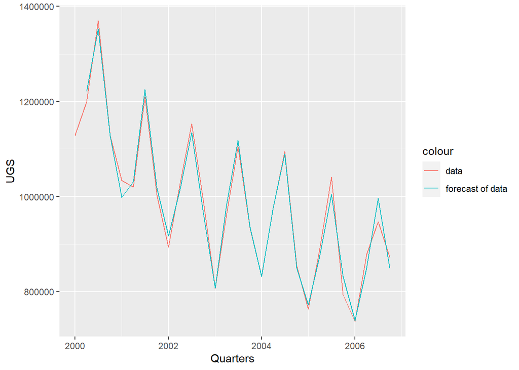

```r
UGS_Data_Table_Model3_Plot=copy(UGS_Data_Table)
UGS_Data_Table_Model3_Plot[,actual:=UGS]
UGS_Data_Table_Model3_Plot[,predicted_trend:=predict(UGS_Data_Table_Model3,UGS_Data_Table_Model3_Plot)]
UGS_Data_Table_Model3_Plot[,residual_trend:=actual-predicted_trend]

ggplot(UGS_Data_Table_Model3_Plot ,aes(x=Quarters)) +
        geom_line(aes(y=UGS,color='data')) +
        geom_line(aes(y=predicted_trend,color='forecast of data'))
```

We can see that our model forecast the actual data properly. So we can use the model.

# 3. Forecasting UGS Values

```r
UGS_Data_Forecast$UGSlag1[1]=UGS_Data_Table$UGS[28]


UGS_Data_Forecast[1,"UGS"]=as.numeric(predict(UGS_Data_Table_Model3,newdata=UGS_Data_Forecast[1,]))
UGS_Data_Forecast[2,"UGS"]=predict(UGS_Data_Table_Model3,newdata=UGS_Data_Forecast[2,])
UGS_Data_Forecast[3,"UGS"]=predict(UGS_Data_Table_Model3,newdata=UGS_Data_Forecast[3,])
UGS_Data_Forecast[4,"UGS"]=predict(UGS_Data_Table_Model3,newdata=UGS_Data_Forecast[4,])

UGS_Data_Forecast$UGSlag1[2]=as.numeric(UGS_Data_Forecast[1,"UGS"])
UGS_Data_Forecast$UGSlag1[3]=as.numeric(UGS_Data_Forecast[2,"UGS"])
UGS_Data_Forecast$UGSlag1[4]=as.numeric(UGS_Data_Forecast[3,"UGS"])

UGS_Data_Forecast[,"UGS"]
```

```
##         UGS
## 1: 677875.0
## 2: 762266.6
## 3: 974275.6
## 4: 861855.9
```